# Final report - Blank group

## Authors: Anders Mellbye, Juan Pablo López Cervantes, Guri Kringeland

#### Due date: 2025-09-27

#### Output: html_document

## Introduction

We were given two databases (main and additional) from the source: Cata et al. ’Blood Storage Duration and Biochemical Recurrence of Cancer after Radical Prostate ctomy’. Mayo Clin Proc 2011; 86(2): 120-127. A clean version is taken from R package medicaldata.

From the description available on the package website: “This data set contains data on 316 men who had undergone radical prostatectomy and received transfusion during or within 30 days of the surgical procedure and had available prostate serum antigen (PSA) follow-up data. The main exposure of interest was RBC storage duration group.”

We had different tasks to develop based on these databases and the new skills learned from R. In the following sections, we describe our work to fulfill these tasks. We hope you’ll enjoy it.

## 1. Create an RStudio project and GitHub repository

We created our GitHub repository named “Blank_exam” to place our documents. There you can find the README file with the overview of our directory.

## 2. Read and tidy the data set.

### First glance

We continued our journey learning about the most useful packages in the R world. We must admit these were first our worst enemies but ended up being friends and allies in this trip. Here an overview of those packages used throughout the course/project.

```r
library(tidyverse)
library(readr)
library(here)
library(skimr)
library(forcats)
library(GGally)
```

Once we were able to understand a bit more about these packages, we started looking at our data. The original data set had 672 rows for 316 IDs and 21 variables. We identified several changes we needed to make on the data set so it could be readable and understandable. For example, we identified duplicated observations (40), some variable names that started either with numbers, spaces or signs: 1_Age. With spaces: T stage, volume measurement, and some variable names that were not so informative.

### Initial round of tidying the data

First we deleted 40 duplicates. Through the pivot wider task ( volumemasurement and .value-> PVol and TVol). rows were halved, now presenting one row per ID for the 316 study subjects.

Then we tidyed the variables, by making new, more intuitive names fore those lacking of one. Columns containing information concerning two variables were either separated (Subject-> Hospital and ID ) or split through pivot wider as mentioned. Columns listed in the assignmet as not of interest was deleted, as asked for in the task. Columns were then sorted with ID being placed first.

The coding was stored by the end of each session, with a script for the same date and a new data set after each session too (we present an overview of the different versions of our data throughout the tidying process).

First tidy version of the data set:

Data summary

| Name | tidy_exam_data |
| --- | --- |
| Number of rows | 632 |
| Number of columns | 22 |
| _______________________ |  |
| Column type frequency: |  |
| character | 3 |
| numeric | 19 |
| ________________________ |  |
| Group variables | None |

**Variable type: character**

| skim_variable | n_missing | complete_rate | min | max | empty | n_unique | whitespace |
| --- | --- | --- | --- | --- | --- | --- | --- |
| Hosp | 0 | 1 | 5 | 5 | 0 | 3 | 0 |
| TimeToRecurrence_unit | 0 | 1 | 3 | 4 | 0 | 2 | 0 |
| Prostate_volume | 0 | 1 | 4 | 4 | 0 | 2 | 0 |

**Variable type: numeric**

| skim_variable | n_missing | complete_rate | mean | sd | p0 | p25 | p50 | p75 | p100 | hist |
| --- | --- | --- | --- | --- | --- | --- | --- | --- | --- | --- |
| ID | 0 | 1.00 | 158.50 | 91.29 | 1.00 | 79.75 | 158.50 | 237.25 | 316.00 | ▇▇▇▇▇ |
| Storage_age_group | 0 | 1.00 | 2.00 | 0.82 | 1.00 | 1.00 | 2.00 | 3.00 | 3.00 | ▇▁▇▁▇ |
| Median_storage_age_group | 0 | 1.00 | 16.71 | 6.28 | 10.00 | 10.00 | 15.00 | 25.00 | 25.00 | ▇▇▁▁▇ |
| Age | 0 | 1.00 | 61.16 | 7.23 | 38.40 | 56.20 | 61.85 | 66.10 | 79.00 | ▁▂▇▇▂ |
| African_american | 0 | 1.00 | 0.17 | 0.38 | 0.00 | 0.00 | 0.00 | 0.00 | 1.00 | ▇▁▁▁▂ |
| Family_history | 0 | 1.00 | 0.22 | 0.41 | 0.00 | 0.00 | 0.00 | 0.00 | 1.00 | ▇▁▁▁▂ |
| Tumor_stage | 26 | 0.96 | 1.11 | 0.32 | 1.00 | 1.00 | 1.00 | 1.00 | 2.00 | ▇▁▁▁▁ |
| Biopsy_gleason_score | 4 | 0.99 | 1.50 | 0.67 | 1.00 | 1.00 | 1.00 | 2.00 | 3.00 | ▇▁▃▁▂ |
| Bladder_neck_positive | 0 | 1.00 | 0.06 | 0.23 | 0.00 | 0.00 | 0.00 | 0.00 | 1.00 | ▇▁▁▁▁ |
| Extra_diagnoses | 0 | 1.00 | 0.66 | 0.48 | 0.00 | 0.00 | 1.00 | 1.00 | 1.00 | ▅▁▁▁▇ |
| Preoperative_PSA | 6 | 0.99 | 8.19 | 6.00 | 1.30 | 4.98 | 6.20 | 9.00 | 40.10 | ▇▂▁▁▁ |
| Preoperative_therapy | 0 | 1.00 | 0.12 | 0.33 | 0.00 | 0.00 | 0.00 | 0.00 | 1.00 | ▇▁▁▁▁ |
| Allogeneic_units | 0 | 1.00 | 2.46 | 1.90 | 1.00 | 2.00 | 2.00 | 2.00 | 19.00 | ▇▁▁▁▁ |
| Adjuvant_therapy | 0 | 1.00 | 0.02 | 0.15 | 0.00 | 0.00 | 0.00 | 0.00 | 1.00 | ▇▁▁▁▁ |
| Adjuvant_radiation_therapy | 0 | 1.00 | 0.00 | 0.06 | 0.00 | 0.00 | 0.00 | 0.00 | 1.00 | ▇▁▁▁▁ |
| Recurrence | 0 | 1.00 | 0.17 | 0.38 | 0.00 | 0.00 | 0.00 | 0.00 | 1.00 | ▇▁▁▁▂ |
| Censor | 0 | 1.00 | 0.83 | 0.38 | 0.00 | 1.00 | 1.00 | 1.00 | 1.00 | ▂▁▁▁▇ |
| TimeToRecurrence | 2 | 1.00 | 52.92 | 70.82 | 0.27 | 10.79 | 35.39 | 67.57 | 476.49 | ▇▁▁▁▁ |
| Value_volume_measurement | 15 | 0.98 | 29.14 | 34.54 | 1.00 | 2.00 | 3.00 | 49.00 | 274.00 | ▇▂▁▁▁ |

## 3. Tidy, adjust, and explore.

### More tidying of the data

Afterwards, when looking over our variables, we wanted to tidy the variable Hosp, deleting characters and keeping the number (1-3) of the treating hospital.

```
data_clean <- exam_data %>%
  separate(
    col = subject,
    into = c("Hosp", "ID"),
    sep = "-"
  )
data_clean
```

Overview of the final tidy version and joining with the additional data set “exam_data.txt”):

Data summary

| Name | joint_exam_data |
| --- | --- |
| Number of rows | 316 |
| Number of columns | 23 |
| _______________________ |  |
| Column type frequency: |  |
| character | 4 |
| numeric | 19 |
| ________________________ |  |
| Group variables | None |

**Variable type: character**

| skim_variable | n_missing | complete_rate | min | max | empty | n_unique | whitespace |
| --- | --- | --- | --- | --- | --- | --- | --- |
| Hosp | 0 | 1.00 | 5 | 5 | 0 | 3 | 0 |
| TimeToRecurrence_unit | 0 | 1.00 | 3 | 4 | 0 | 2 | 0 |
| PVol_HighLow | 9 | 0.97 | 3 | 4 | 0 | 2 | 0 |
| Recurrence2 | 0 | 1.00 | 2 | 3 | 0 | 2 | 0 |

**Variable type: numeric**

| skim_variable | n_missing | complete_rate | mean | sd | p0 | p25 | p50 | p75 | p100 | hist |
| --- | --- | --- | --- | --- | --- | --- | --- | --- | --- | --- |
| ID | 0 | 1.00 | 158.50 | 91.37 | 1.00 | 79.75 | 158.50 | 237.25 | 316.00 | ▇▇▇▇▇ |
| Age | 0 | 1.00 | 61.16 | 7.24 | 38.40 | 56.20 | 61.85 | 66.10 | 79.00 | ▁▂▇▇▂ |
| Storage_age_group | 0 | 1.00 | 2.00 | 0.82 | 1.00 | 1.00 | 2.00 | 3.00 | 3.00 | ▇▁▇▁▇ |
| Median_storage_age_group | 0 | 1.00 | 16.71 | 6.28 | 10.00 | 10.00 | 15.00 | 25.00 | 25.00 | ▇▇▁▁▇ |
| Family_history | 0 | 1.00 | 0.22 | 0.41 | 0.00 | 0.00 | 0.00 | 0.00 | 1.00 | ▇▁▁▁▂ |
| Tumor_stage | 13 | 0.96 | 1.11 | 0.32 | 1.00 | 1.00 | 1.00 | 1.00 | 2.00 | ▇▁▁▁▁ |
| Preoperative_PSA | 3 | 0.99 | 8.19 | 6.01 | 1.30 | 4.98 | 6.20 | 9.00 | 40.10 | ▇▂▁▁▁ |
| Preoperative_therapy | 0 | 1.00 | 0.12 | 0.33 | 0.00 | 0.00 | 0.00 | 0.00 | 1.00 | ▇▁▁▁▁ |
| Allogeneic_units | 0 | 1.00 | 2.46 | 1.90 | 1.00 | 2.00 | 2.00 | 2.00 | 19.00 | ▇▁▁▁▁ |
| Adjuvant_therapy | 0 | 1.00 | 0.02 | 0.15 | 0.00 | 0.00 | 0.00 | 0.00 | 1.00 | ▇▁▁▁▁ |
| Adjuvant_radiation_therapy | 0 | 1.00 | 0.00 | 0.06 | 0.00 | 0.00 | 0.00 | 0.00 | 1.00 | ▇▁▁▁▁ |
| Recurrence | 0 | 1.00 | 0.17 | 0.38 | 0.00 | 0.00 | 0.00 | 0.00 | 1.00 | ▇▁▁▁▂ |
| Censor | 0 | 1.00 | 0.83 | 0.38 | 0.00 | 1.00 | 1.00 | 1.00 | 1.00 | ▂▁▁▁▇ |
| TimeToRecurrence | 1 | 1.00 | 52.92 | 70.88 | 0.27 | 10.80 | 35.39 | 67.38 | 476.49 | ▇▁▁▁▁ |
| TimeToRecurrence_days | 1 | 1.00 | 370.42 | 496.13 | 2.00 | 75.50 | 248.00 | 471.50 | 3335.00 | ▇▁▁▁▁ |
| PVol | 9 | 0.97 | 56.45 | 30.20 | 19.40 | 40.85 | 49.00 | 64.05 | 274.00 | ▇▂▁▁▁ |
| TVol | 6 | 0.98 | 2.09 | 0.71 | 1.00 | 2.00 | 2.00 | 3.00 | 3.00 | ▃▁▇▁▅ |
| TotalTherapy | 0 | 1.00 | 0.00 | 0.06 | 0.00 | 0.00 | 0.00 | 0.00 | 1.00 | ▇▁▁▁▁ |
| sGS | 116 | 0.63 | 2.58 | 0.82 | 1.00 | 2.00 | 3.00 | 3.00 | 4.00 | ▂▃▁▇▁ |

On this new joint dataset, we created a new variable “TimeToRecurrence_days_new”, with the purpose of making the variable “TimeToRecurrence_weeks_new”, for calculations with the same numeric category (weeks). We met a little rocky road making this new variable, therefore keeping some duplicates to remember the steps of the string.

```
joint_exam_data <- read_tsv(here("data", "joint_exam_data_2025-09-09.txt")) %>%
  # New variabler
  mutate(
    unit_norm = str_to_lower(str_trim(TimeToRecurrence_unit)),
    ttr_num = parse_number(as.character(TimeToRecurrence)),
    TimeToRecurrence_days_new = case_when(
      str_starts(unit_norm, "week") ~ ttr_num * 7,
      str_starts(unit_norm, "day") ~ ttr_num,
      TRUE ~ NA_real_
    ),
    TimeToRecurrence_weeks_new = as.integer(round(TimeToRecurrence_days_new / 7, 0)),
    TimeToRecurrence_days_new = as.integer(round(TimeToRecurrence_days_new, 0)),
    Hospital = gsub("Hosp", "", Hosp)
  )


### This is to delete the old column - timetoreccurance_days ----
joint_exam_data <- joint_exam_data %>%
  select(-any_of(c("TimeToRecurrence_days", "timetoreccurance_days")))

# quick overview
glimpse(joint_exam_data)
```

Once we were done with these changes and joining our data sets, we began exploring our variables in detail, based on the following instructions (we include the commands we used for each task):

1. Stratify your data by a categorical column and report min, max, mean and sd of a numeric column.

```
joint_exam_data %>%
  group_by(Tumor_stage_lab = if_else(is.na(Tumor_stage), "Missing", as.character(Tumor_stage))) %>%
  summarise(
    n = n(),
    min = min(Preoperative_PSA, na.rm = TRUE),
    max = max(Preoperative_PSA, na.rm = TRUE),
    mean = mean(Preoperative_PSA, na.rm = TRUE),
    sd = sd(Preoperative_PSA, na.rm = TRUE),
    .groups = "drop"
  )

glimpse(joint_exam_data)
```

2. Stratify your data by a categorical column and report min, max, mean and sd of a numeric column for a defined set of observations
- Only for persons with `T.Stage == 1`

```
joint_exam_data %>%
  group_by(Recurrence2) %>%
  filter(Tumor_stage == 1) %>%
  summarise(
    min_pvol = min(PVol, na.rm = TRUE),
    max_pvol = max(PVol, na.rm = TRUE),
    mean_pvol = mean(PVol, na.rm = TRUE),
    sd_pvol = sd(PVol, na.rm = TRUE)
  )
```

- Only for persons with `Median.RBC.Age == 25`

```
joint_exam_data %>%
  group_by(Recurrence2) %>%
  filter(Median_storage_age_group == 25) %>%
  summarise(
    min_pvol = min(PVol, na.rm = TRUE),
    max_pvol = max(PVol, na.rm = TRUE),
    mean_pvol = mean(PVol, na.rm = TRUE),
    sd_pvol = sd(PVol, na.rm = TRUE)
  )
```

- Only for persons with `TimeToReccurence` later than 4 weeks

```
joint_exam_data %>%
  filter(TimeToRecurrence_weeks_new > 4) %>%
  group_by(Recurrence2) %>%
  summarise(
    min_pvol = min(PVol, na.rm = TRUE),
    max_pvol = max(PVol, na.rm = TRUE),
    mean_pvol = mean(PVol, na.rm = TRUE),
    sd_pvol = sd(PVol, na.rm = TRUE)
  )
glimpse(joint_exam_data)
```

- Only for persons recruited in `Hospital 1` and `Tvol == 2`

```
joint_exam_data %>%
  filter(Hospital == "1", TVol == 2) %>%
  group_by(Recurrence2) %>%
  summarise(
    min_pvol = min(PVol, na.rm = TRUE),
    max_pvol = max(PVol, na.rm = TRUE),
    mean_pvol = mean(PVol, na.rm = TRUE),
    sd_pvol = sd(PVol, na.rm = TRUE)
  )

glimpse(joint_exam_data)
```

- Use two categorical columns in your dataset to create a table (either with `table()`, `count()`, or `janitor::tabyl()`)

```
joint_exam_data %>%
  mutate(
    Tumor_stage = fct_explicit_na(as.factor(Tumor_stage), na_level = "Missing"),
    Hospital = as.factor(Hospital)
  ) %>%
  count(Tumor_stage, Hospital, name = "n", .drop = FALSE) %>%
  pivot_wider(names_from = Hospital, values_from = n, values_fill = 0)
```

After the latest tidying we and the stratifying work, we saved the dataset with the new name ggplot_exam_data, as getting ready for task 4 concerning ggplot.

```
fileName <- here("data", paste0("ggplot_exam_data_", Sys.Date(), ".txt"))
write_delim(
  joint_exam_data,
  file = fileName,
  delim = "\t"
)
```

Overview of our last data set before working on making figures.

Data summary

| Name | ggplot_exam_data |
| --- | --- |
| Number of rows | 316 |
| Number of columns | 26 |
| _______________________ |  |
| Column type frequency: |  |
| character | 4 |
| numeric | 22 |
| ________________________ |  |
| Group variables | None |

**Variable type: character**

| skim_variable | n_missing | complete_rate | min | max | empty | n_unique | whitespace |
| --- | --- | --- | --- | --- | --- | --- | --- |
| TimeToRecurrence_unit | 0 | 1.00 | 3 | 4 | 0 | 2 | 0 |
| PVol_HighLow | 9 | 0.97 | 3 | 4 | 0 | 2 | 0 |
| Recurrence2 | 0 | 1.00 | 2 | 3 | 0 | 2 | 0 |
| unit_norm | 0 | 1.00 | 3 | 4 | 0 | 2 | 0 |

**Variable type: numeric**

| skim_variable | n_missing | complete_rate | mean | sd | p0 | p25 | p50 | p75 | p100 | hist |
| --- | --- | --- | --- | --- | --- | --- | --- | --- | --- | --- |
| ID | 0 | 1.00 | 158.50 | 91.37 | 1.00 | 79.75 | 158.50 | 237.25 | 316.00 | ▇▇▇▇▇ |
| Hospital | 0 | 1.00 | 2.16 | 0.78 | 1.00 | 2.00 | 2.00 | 3.00 | 3.00 | ▅▁▇▁▇ |
| Age | 0 | 1.00 | 61.16 | 7.24 | 38.40 | 56.20 | 61.85 | 66.10 | 79.00 | ▁▂▇▇▂ |
| Storage_age_group | 0 | 1.00 | 2.00 | 0.82 | 1.00 | 1.00 | 2.00 | 3.00 | 3.00 | ▇▁▇▁▇ |
| Median_storage_age_group | 0 | 1.00 | 16.71 | 6.28 | 10.00 | 10.00 | 15.00 | 25.00 | 25.00 | ▇▇▁▁▇ |
| Family_history | 0 | 1.00 | 0.22 | 0.41 | 0.00 | 0.00 | 0.00 | 0.00 | 1.00 | ▇▁▁▁▂ |
| Tumor_stage | 13 | 0.96 | 1.11 | 0.32 | 1.00 | 1.00 | 1.00 | 1.00 | 2.00 | ▇▁▁▁▁ |
| Preoperative_PSA | 3 | 0.99 | 8.19 | 6.01 | 1.30 | 4.98 | 6.20 | 9.00 | 40.10 | ▇▂▁▁▁ |
| Preoperative_therapy | 0 | 1.00 | 0.12 | 0.33 | 0.00 | 0.00 | 0.00 | 0.00 | 1.00 | ▇▁▁▁▁ |
| Allogeneic_units | 0 | 1.00 | 2.46 | 1.90 | 1.00 | 2.00 | 2.00 | 2.00 | 19.00 | ▇▁▁▁▁ |
| Adjuvant_therapy | 0 | 1.00 | 0.02 | 0.15 | 0.00 | 0.00 | 0.00 | 0.00 | 1.00 | ▇▁▁▁▁ |
| Adjuvant_radiation_therapy | 0 | 1.00 | 0.00 | 0.06 | 0.00 | 0.00 | 0.00 | 0.00 | 1.00 | ▇▁▁▁▁ |
| Recurrence | 0 | 1.00 | 0.17 | 0.38 | 0.00 | 0.00 | 0.00 | 0.00 | 1.00 | ▇▁▁▁▂ |
| Censor | 0 | 1.00 | 0.83 | 0.38 | 0.00 | 1.00 | 1.00 | 1.00 | 1.00 | ▂▁▁▁▇ |
| TimeToRecurrence | 1 | 1.00 | 52.92 | 70.88 | 0.27 | 10.80 | 35.39 | 67.38 | 476.49 | ▇▁▁▁▁ |
| PVol | 9 | 0.97 | 56.45 | 30.20 | 19.40 | 40.85 | 49.00 | 64.05 | 274.00 | ▇▂▁▁▁ |
| TVol | 6 | 0.98 | 2.09 | 0.71 | 1.00 | 2.00 | 2.00 | 3.00 | 3.00 | ▃▁▇▁▅ |
| TotalTherapy | 0 | 1.00 | 0.00 | 0.06 | 0.00 | 0.00 | 0.00 | 0.00 | 1.00 | ▇▁▁▁▁ |
| sGS | 116 | 0.63 | 2.58 | 0.82 | 1.00 | 2.00 | 3.00 | 3.00 | 4.00 | ▂▃▁▇▁ |
| ttr_num | 1 | 1.00 | 52.92 | 70.88 | 0.27 | 10.80 | 35.39 | 67.38 | 476.49 | ▇▁▁▁▁ |
| TimeToRecurrence_days_new | 1 | 1.00 | 230.40 | 199.89 | 2.00 | 53.00 | 177.00 | 364.00 | 725.00 | ▇▃▃▂▂ |
| TimeToRecurrence_weeks_new | 1 | 1.00 | 32.92 | 28.59 | 0.00 | 8.00 | 25.00 | 52.00 | 104.00 | ▇▃▃▂▂ |

Additionally, we created a supplementary codebook based on the variables we created, changed and renamed.

[output not shown]

## 4. Create plots

After a fun session on looking at how to create and format plots in R, we were able to create some nice figures (according to us) to try to answer the following questions. Before each figure, we included the script we used to build these plots according to each task (just for informative purposes).

1. Are there any correlated measurements? (hint: `GGally::ggcorr` or search online for correlation matrix in R)

```
library(dplyr)
library(GGally)
library(tidyverse)
library(ggcorrplot)

## Choosing solely numeric columns and filtrating columns that causes issues (missing N/A, or ID)
num <- ggplot_exam_data %>%
  select(where(is.numeric)) %>%
  select(-any_of(c("ID", "ttr_num", "TimeToRecurrence_weeks_new"))) %>%
  mutate(across(everything(), ~ ifelse(is.finite(.), ., NA_real_))) %>%
  select(where(~ sum(!is.na(.)) >= 3)) %>%
  select(where(~ sd(., na.rm = TRUE) > 0))

## Making a correlation matrix
cm <- cor(num, use = "pairwise.complete.obs", method = "pearson")

## Filtering
ok <- (rowSums(!is.finite(cm)) == 0) & (colSums(!is.finite(cm)) == 0)
cm_ok <- cm[ok, ok, drop = FALSE]

## Shorter labels
labs <- make.unique(abbreviate(colnames(cm_ok), minlength = 12))
colnames(cm_ok) <- rownames(cm_ok) <- labs

## Making the heatmap
plot_1 <- ggcorrplot(
  cm_ok,
  type = "lower",
  lab = FALSE,
  outline.col = "white",
  show.diag = TRUE,
  hc.order = TRUE
) +
  theme(
    axis.text.x = element_text(angle = 45, hjust = 1, vjust = 1, size = 8),
    axis.text.y = element_text(size = 8)
  )

plot_1
```

##### **Figure 1**: Heatmap with correlation matrix

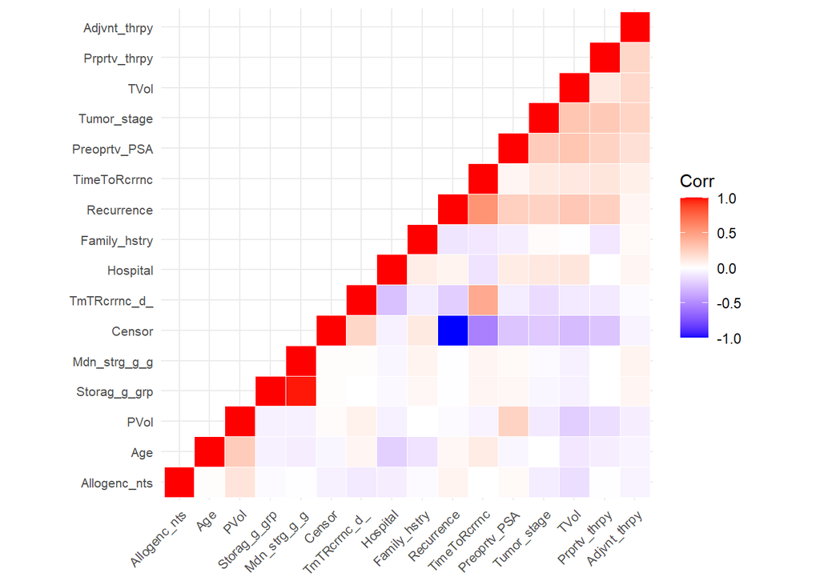

2. Is there a relation between the `PVol` and `TVol` variables?

```
ggplot_exam_data2 <- ggplot_exam_data %>%
  select(PVol, TVol) %>%
  filter(!is.na(PVol), !is.na(TVol))

# Checking for correlation
spear <- cor.test(ggplot_exam_data2$PVol, ggplot_exam_data2$TVol, method = "spearman")

spear

# Setting up for the plot
dat <- read_tsv(here("data","ggplot_exam_data_2025-09-10.txt")) %>%
  select(PVol, TVol) %>%
  filter(is.finite(PVol), is.finite(TVol), PVol > 0) %>% # log10 trenger PVol > 0
  mutate(TVol = factor(TVol))

# Creating the boxplot and jitter
plot_2 <- ggplot(dat, aes(TVol, PVol)) +
  geom_boxplot(outlier.shape = NA) +
  geom_jitter(width = 0.15, alpha = 0.5, size = 1) +
  scale_y_log10() +
  labs(
    title = "PVol by TVol",
    x = "TVol (category)",
    y = "PVol (log10 scale)"
  ) +
  theme_minimal()

plot_2

# Adding Spearman correlation to the boxplot
sp <- cor.test(dat$PVol, as.numeric(dat$TVol), method = "spearman")
plot_2a <- plot_2 + annotate("text",
  x = Inf, y = Inf,
  label = sprintf(
    "Spearman rho = %.2f, p = %.3g",
    sp$estimate, sp$p.value
  ),
  hjust = 1.05, vjust = 1.5, size = 4
)

plot_2a
```

##### **Figure 2**: Boxplot and Spearman correlation coefficient of the relation between Prostate Volumen (PVol) and Tumor Volume (TVol)

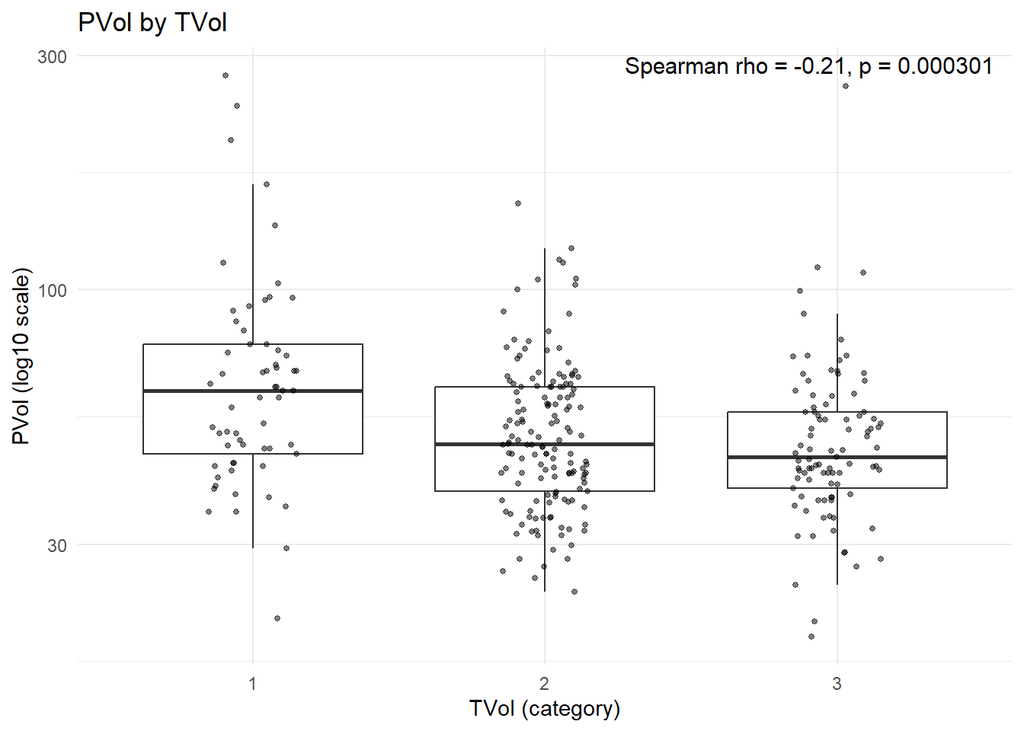

ANSWER: This figure shows the distribution of prostate volume (PVol, log10 scale) across tumor volume (TVol) categories. Median PVol tends to be higher in men with lower TVol categories, with a gradual decline as TVol increases. The negative correlation is confirmed by a Spearman rank correlation coefficient of –0.21 (p = 0.0003), indicating that larger tumor volume is modestly but significantly associated with smaller prostate volume.

3. Does the distribution of `PreopPSA` differ by `T.Stage`?

```
plot_3 <- ggplot(ggplot_exam_data, aes(x = factor(Tumor_stage), y = Preoperative_PSA)) +
  geom_boxplot(fill = "lightblue", color = "darkblue") +
  labs(
    title = "Distribution of Preoperative PSA by Tumor stage",
    x = "Tumor stage",
    y = "Preoperative PSA"
  ) +
  theme_minimal()
summary(ggplot_exam_data$Preoperative_PSA)
summary(ggplot_exam_data$Tumor_stage)

plot_3
```

##### **Figure 3**: Boxplot of the distribution of Preoperative Prostate Specific Antigen (PSA) across Tumor Stages

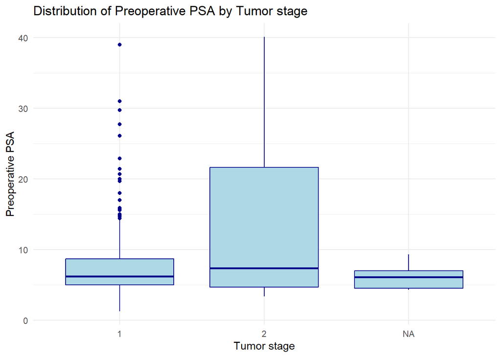

ANSWER: The distribution of preoperative PSA (PreopPSA) appears to differ by tumor stage. For instance, patients with stage 1 tumors had lower PSA values, though with several high outliers. Those with stage 2 tumors showed a broader spread and higher median PSA compared to stage 1, indicating more variability and higher levels overall. Overall, this suggests that higher tumor stage is associated with higher and more variable preoperative PSA levels.

4. Does the distribution of `PVol` differ by `sGS`?

```
plot_4 <- ggplot(ggplot_exam_data, aes(x = factor(sGS), y = PVol)) +
  geom_boxplot(fill = "lightblue", color = "darkblue") +
  labs(
    title = "Distribution of Prostate Volume by Surgical Gleason score",
    x = "Surgical Gleason Score",
    y = "Prostate Volume"
  ) +
  theme_minimal()

plot_4
```

##### **Figure 4**: Boxplot of the distribution of Prostate volume across Surgical Gleason Score

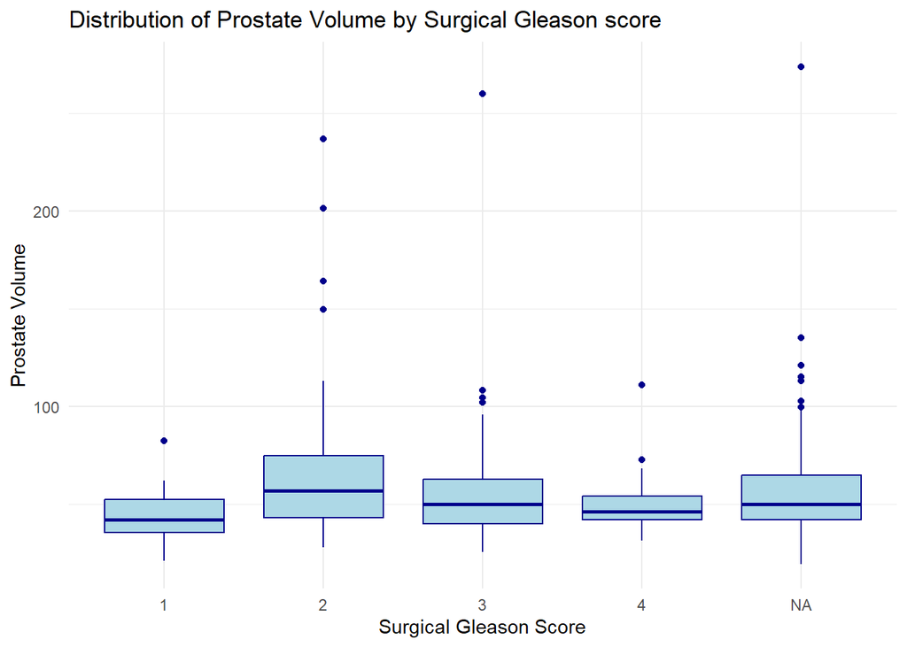

ANSWER: Yes, we can see that the distribution of prostate volume differs by surgical Gleason score. While the medians don’t shift dramatically, the variability and number of outliers differ substantially. For instance, sGS = 2 has the broadest distribution with more very large prostate volumes, whereas sGS = 1 and 4 are tighter.

5. Does the distribution of `TVol` differ by `sGS`?

```
plot_5 <- ggplot(ggplot_exam_data, aes(x = factor(sGS), y = TVol)) +
  geom_boxplot(fill = "lightblue", color = "darkblue") +
  labs(
    title = "Distribution of Tumor Volume by Surgical Gleason score",
    x = "Surgical Gleason Score",
    y = "Tumor Volume"
  ) +
  theme_minimal()

plot_5
```

##### **Figures 5 and 6**: Distribution of Tumor volume across Surgical Gleason Score

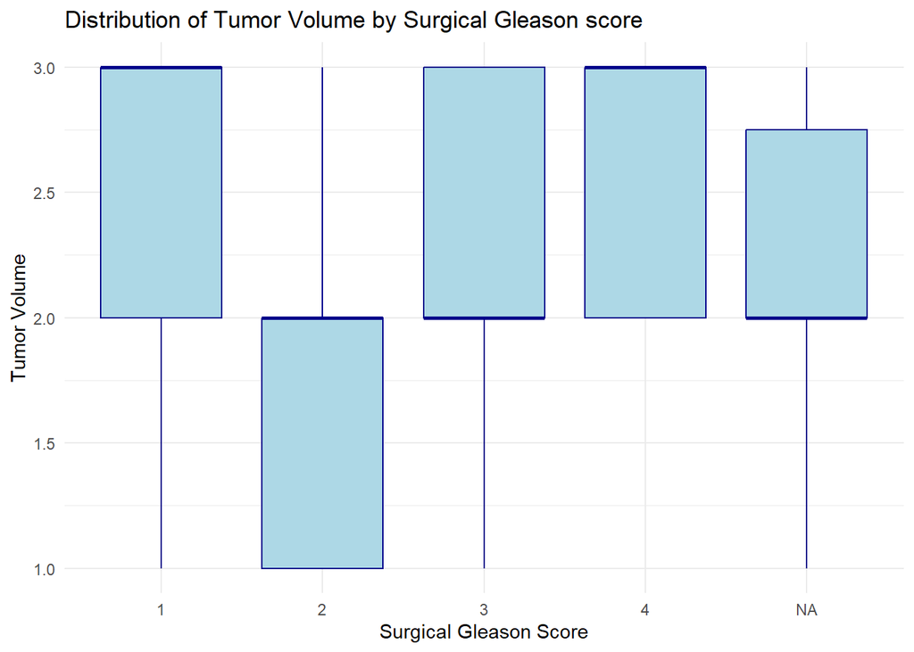

```
plot_5b <- ggplot_exam_data %>%
  ggplot(aes(x = factor(TVol), fill = factor(sGS))) +
  geom_bar(position = "dodge") +
  labs(
    title = "Distribution of Tumor volume by Gleason score",
    x = "Tumor volume",
    y = "Number of patients",
    fill = "sGS (postoperative Gleason score)"
  ) +
  theme_minimal()

plot_5b
```

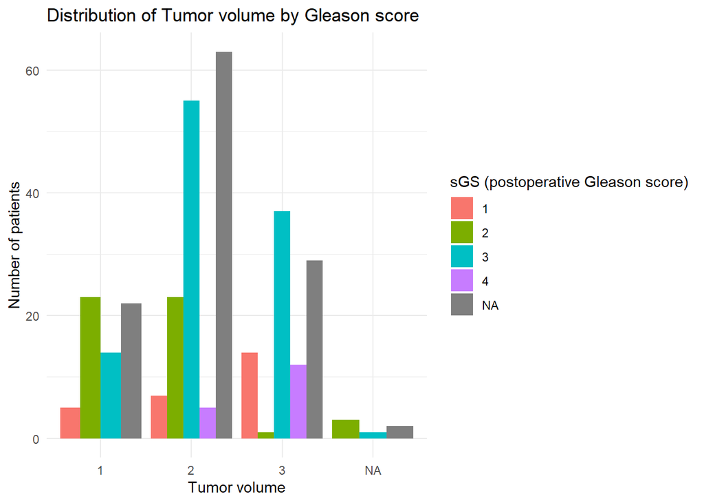

6. Where there more `T.Stage == 2` in the group with `PreopTherapy == 1` than in the group `PreopTherapy == 0`?

```
plot_6_1 <- ggplot_exam_data %>%
  mutate(Preoperative_therapy2 = if_else(Preoperative_therapy == "0", "No", "Yes")) %>%
  filter(Tumor_stage == 2) %>%
  ggplot(aes(Preoperative_therapy2)) +
  geom_bar(width = 0.3, fill = "darkblue")
plot_6_1

plot_6_2 <- plot_6_1 +
  xlab("Preoperative therapy") +
  ylab("Number of patients") +
  labs(
    title = "Number of patients with tumor stage 2",
    subtitle = "stratified by preoperative therapy groups"
  )

plot_6_2

plot_6 <- plot_6_2 +
  theme(
    plot.title = element_text(
      size = 20,
      face = "bold"
    )
  ) +
  theme_minimal()

plot_6
```

##### **Figure 7**: Distribution of patients with Tumor Stage 2, by preoperative therapy groups

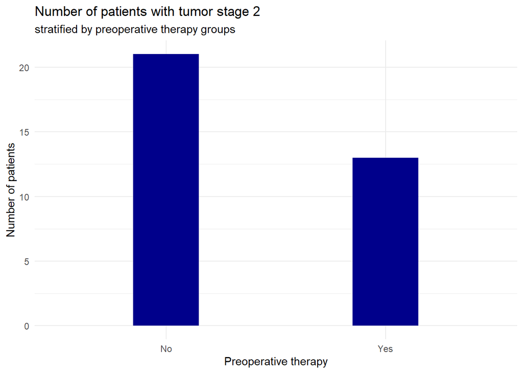

ANSWER: There is a clear difference in the amount of patients with Tumor Stage 2 by Preoperative therapy, with more patients in the group that did not receive this therapy before the operation.

## 5. Analysing the data

We also did a minor change in the dataset through renaming the sGS column to Surgical_gleason_score for tidying purposes.

See the full analysis script here: Script_sixthday_2025-11-09.R

## 6. Final remarks

After tidying several times, joining, more tyiding, stratifying data, showing several overviews of our different data sets, creating plots and analyzing the results, we have finally come to the end of our work report. We must admit this course and the work felt like a roller coaster, with fun and very productive days when all the commands, libraries and tables came through, and with days when when not even RStudio would open. We tried to do our best on this report and have fun while working on it. We hope is clear and complete enough for you to approve it. Thank you for reading it.

THE BLANK TEAM (that is not so blank anymore after this course).

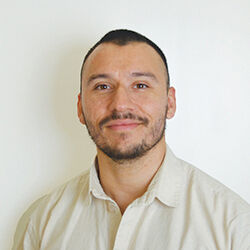

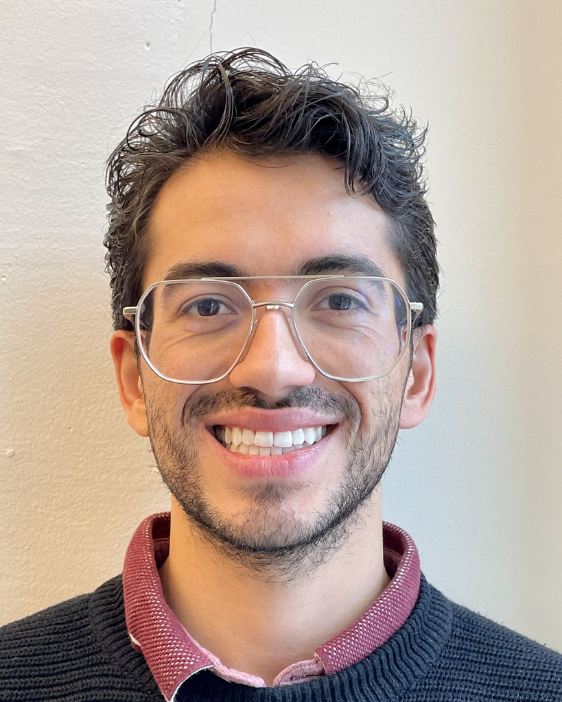

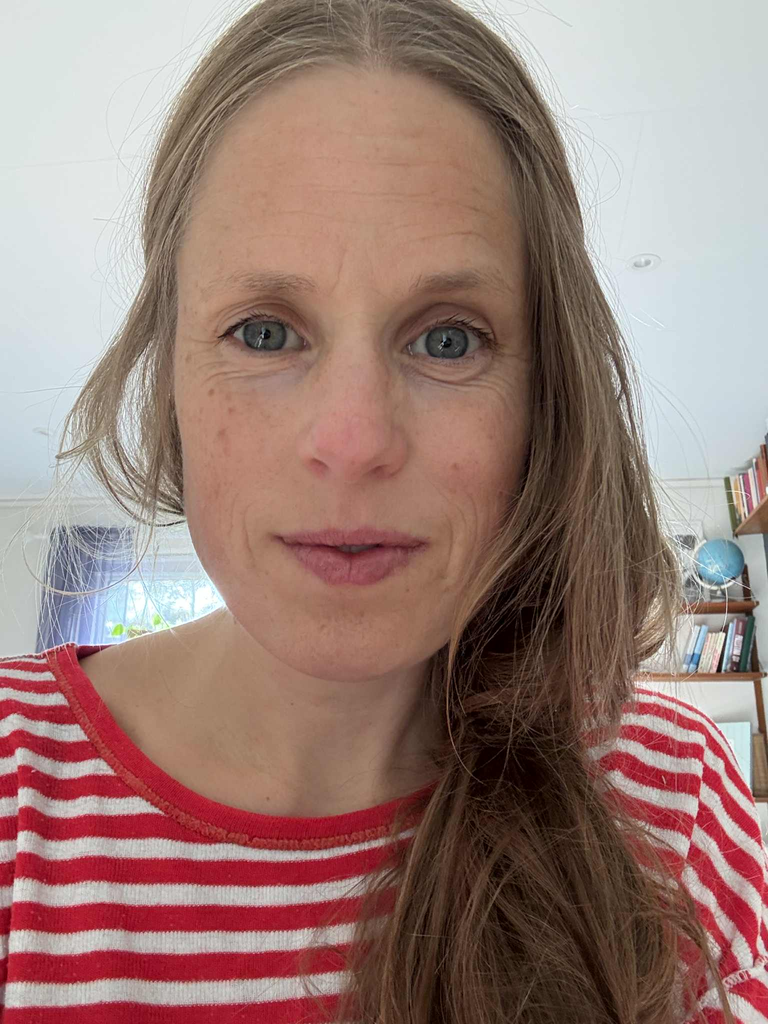